# Illustration of getHierLevel function for finding and selecting relevant groups of variable

Florent Guinot

2018-08-23

# Example of a single data set

We consider here a single data with correlated predictors related to a phenotype.

Let us first load some packages for data generation.

```r
library(SIComORe)
library(Matrix)
library(mvtnorm)
```

## Data generation

### Input matrix of predictors

Now, let us to draw some data: we consider 200 variables spreaded in 3 groups of 30 variables + 110 groups with a single variable. Only groups 1 and 2 will be relevant for the phenotype

```r
p <- 200  # the number of features
K <- 113  # number of groups
## 2 relevants groups with 30 variables
## 1 irrelevant group with 30 variables
## 110 irrelevant groups with a single variable
grp.size <- c(30, 30, 30, rep(1,110))
```

We draw 100 observation of a Gaussian vector the covariance of which has a block structure faithfull to the original grouping of the variables.

```r
## covariance defined blockwise
n <- 100
rhos <- runif(K,.5,.95) # correlation within groups
Sigma <- bdiag(lapply(1:K, function(k) return(matrix(rhos[k],grp.size[k],grp.size[k]))))
diag(Sigma) <- 1
grp <- rep(1:length(grp.size), grp.size)
X <- Sigma %>%
  as.matrix() %>%
  rmvnorm(n, sigma=.) %>%
  scale()
```

The matrix of empirical correlation is rather convincing:

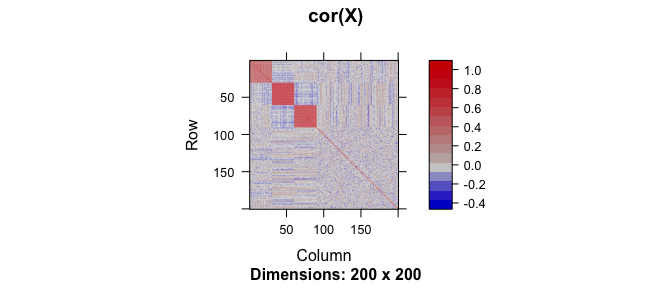

```r
X %>%
  cor() %>%
  Matrix %>%
  image(main="cor(X)")
```

### Phenotype/Response vector

The phenotype will be a linear combinason of the *compressed* version of the predictors. Here, we use the mean to compressed the variable which are in the same group:

```r
X.comp <- t(rowsum(t(X), grp)/tabulate(grp))
```

The vector of regression parameters is sparse, chosen such that the first two group are predictive:

```r
dim.theta <- ncol(X.comp)
theta <- rep(0, dim.theta)
theta[c(1,2)] <- runif(2, min=5, max=10) ## simple effects on the first two groups
```

```r
sigma <- 5
epsilon <- rnorm(n) * sigma
epsilon.test <- rnorm(n) * sigma
y <- X.comp %*% theta + epsilon
r2 <- 1-sum(epsilon^2) / sum((y-mean(y))^2)
r2
```

```
## [1] 0.8251094
```

## Adjusting a single hierarchy

Now, we try to recover the correct level of compression only from the original input matrix and the response vector. We test all the level of a hierarchy obtained by a WARD hierarchical clustering. The grouping is rather obvious in this case:

### Retreiving a hierarchy

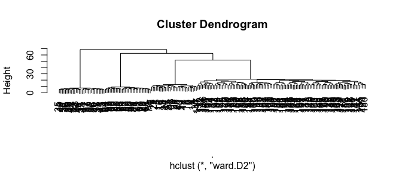

```r
hierarchy <- X %>%
  scale() %>%
  t() %>%
  dist() %>%
  hclust(method="ward.D2")
plot(hierarchy)
```

### Variable selection along the hierarchy

We try the 3 available options in our package for simultaneously finding and selecting the groups of variables related to the phenotype:

```r
out.hcar  <- getHierLevel(X, y, hierarchy, choice="lambda.1se", selection="hcar", mc.cores=NULL)
out.mlgl  <- getHierLevel(X, y, hierarchy, choice="lambda.1se", selection="mlgl", mc.cores=NULL)
out.sicomore <- getHierLevel(X, y, hierarchy, choice="lambda.1se", selection="sicomore", mc.cores=NULL)
```

The three models show comparable estimated prediction error on the best level of the hierarchy:

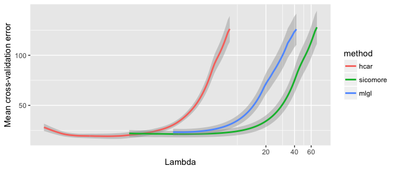

```r
all.cv <- rbind(cbind(out.hcar$cv.error , method="hcar"),
                cbind(out.sicomore$cv.error, method="sicomore"),
                cbind(out.mlgl$cv.error , method="mlgl"))

all.cv %>%
  ggplot(aes(x=lambda, y=mean, colour=method, group=method)) +
  geom_smooth(aes(ymin=mean-sd, ymax=mean+sd), stat="identity") +
   labs(y = "Mean cross-validation error", x = "Lambda") +
  coord_trans(x="log")
```

In terms of variables selections,

```r
out.mlgl$getGrp()
```

```
## [[1]]
##  [1] 31 32 33 34 35 36 37 38 39 40 41 42 43 44 45 46 47 48 49 50 51 52 53
## [24] 54 55 56 57 58 59 60
##
## [[2]]
##  [1]  1  2  3  4  5  6  7  8  9 10 11 12 13 14 15 16 17 18 19 20 21 22 23
## [24] 24 25 26 27 28 29 30
```

```r
out.hcar$getGrp()
```

```
## [[1]]
##  [1]  1  5  8 12 13 16 17 19 22 24
##
## [[2]]
## [1]  2  4  6  9 11 30
##
## [[3]]
## [1]  7 10 14 15 20 21 29
##
## [[4]]
##  [1] 31 32 33 34 35 36 37 38 39 40 41 42 43 44 45 46 47 48 49 50 51 52 53
## [24] 54 55 56 57 58 59 60
##
## [[5]]
## [1] 91
##
## [[6]]
## [1] 94
##
## [[7]]
## [1] 110
##
## [[8]]
## [1] 127
##
## [[9]]
## [1] 166
```

```r
out.sicomore$getGrp()
```

```
## [[1]]
##  [1]  1  2  3  4  5  6  7  8  9 10 11 12 13 14 15 16 17 18 19 20 21 22 23
## [24] 24 25 26 27 28 29 30
##
## [[2]]
##  [1] 31 32 33 34 35 36 37 38 39 40 41 42 43 44 45 46 47 48 49 50 51 52 53
## [24] 54 55 56 57 58 59 60
```

## Comparison of computation time between the 3 options:

```r
SICOMORE <- expression(getHierLevel(X, y, hierarchy, choice="lambda.1se", selection="sicomore", mc.cores=NULL))
MLGL <- expression(getHierLevel(X, y, hierarchy, choice="lambda.1se", selection="mlgl", mc.cores=NULL))
HCAR <- expression(getHierLevel(X, y, hierarchy, choice="lambda.1se", selection="hcar", mc.cores=NULL))
bench <- microbenchmark(eval(SICOMORE) , eval(MLGL), eval(HCAR), times = 50)
```

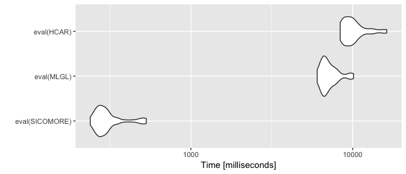

```r
autoplot(bench)
```